# hw3

```python
import csv
import pandas as pd
import seaborn as sb
import matplotlib.pyplot as plt
csv_file = 'data_h3_3337.csv'
```

```python
df = pd.read_csv(csv_file)
df.head()
```

|  | CustomerID | Gender | Age | Annual Income (k$) | Spending Score (1-100) |
| --- | --- | --- | --- | --- | --- |
| 0 | 1 | Male | 19 | 15 | 39 |
| 1 | 2 | Male | 21 | 15 | 81 |
| 2 | 3 | Female | 20 | 16 | 6 |
| 3 | 4 | Female | 23 | 16 | 77 |
| 4 | 5 | Female | 31 | 17 | 40 |

A business provides you with the following data and wants you to find patterns in their customer's habits so that they can make better recommendations and target certain groups in the future.

Would we approach this as a supervised or unsupervised learning task and why?

We would approach this as a supervised learning task because we have "correct" data we can work off of, and we can see how different features will affect our target variable "spending score".

```python
df.info()
```

```
<class 'pandas.core.frame.DataFrame'>
RangeIndex: 200 entries, 0 to 199
Data columns (total 5 columns):
 #   Column                  Non-Null Count  Dtype
---  ------                  --------------  -----
 0   CustomerID              200 non-null    int64
 1   Gender                  200 non-null    object
 2   Age                     200 non-null    int64
 3   Annual Income (k$)      200 non-null    int64
 4   Spending Score (1-100)  200 non-null    int64
dtypes: int64(4), object(1)
memory usage: 7.9+ KB
```

```python
columns = ['CustomerID',	'Gender',	'Age'	,'Annual Income (k$)',	'Spending Score (1-100)']
for x in columns:
    uniquecount = df[x].nunique()
    print(x,uniquecount)
```

```
CustomerID 200
Gender 2
Age 51
Annual Income (k$) 64
Spending Score (1-100) 84
```

data looks clean with no null values. 200 observations. 2 genders, 51 different ages, 64 unique annual incomes, and 84 different spending scores in our data sample

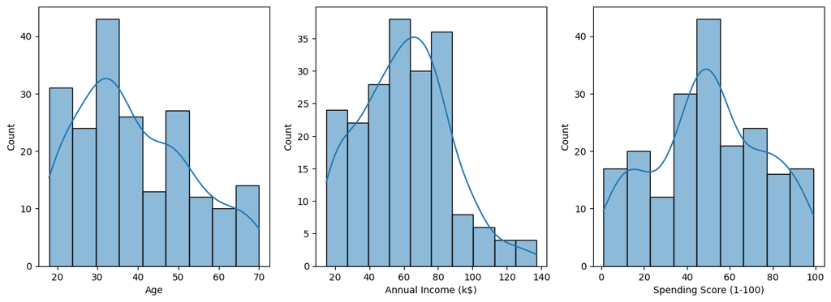

```python
fig, axes = plt.subplots(nrows=1, ncols=3,figsize=(15, 5))

sb.histplot(df['Age'], kde=True,ax = axes[0])
sb.histplot(df['Annual Income (k$)'], kde=True, ax=axes[1])
sb.histplot(df['Spending Score (1-100)'], kde=True,ax=axes[2])
```

Annual income mostly between 60k and 80k. Skewed to the right because of a few higher income data points.

Spending score on average is 50 normally distributed.

```
(-1.0999998909991102,
 1.0999999948094814,
 -1.0999929225079865,
 1.0999987877686102)
```

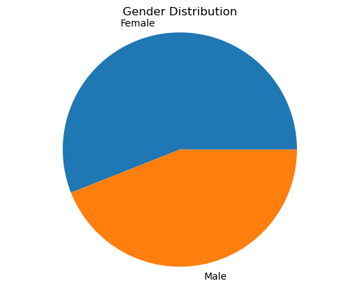

```python
gender_counts = df['Gender'].value_counts()
plt.pie(gender_counts, labels=gender_counts.index)
plt.title('Gender Distribution')
plt.axis('equal')
```

This plot shows that there are more females than males in our sampling set, about 60% to 40%.

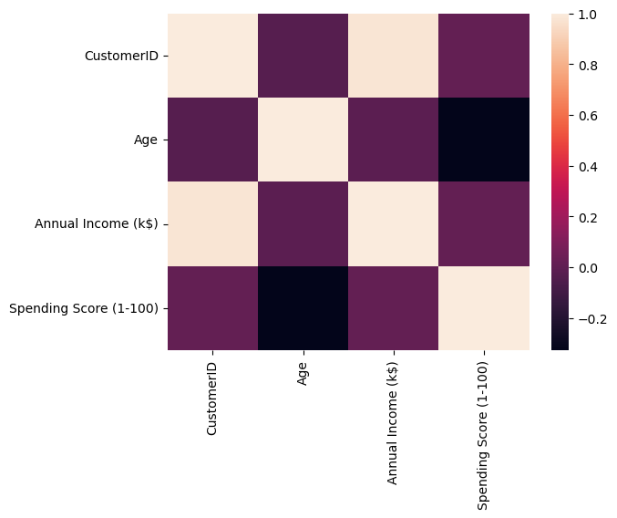

```python
dropdf = df.drop(columns = 'Gender')
sb.heatmap(dropdf.corr())
```

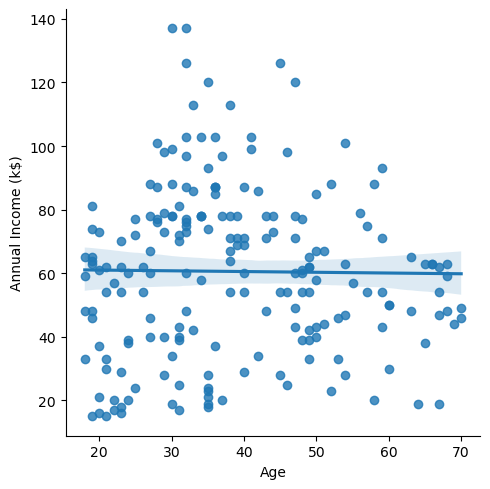

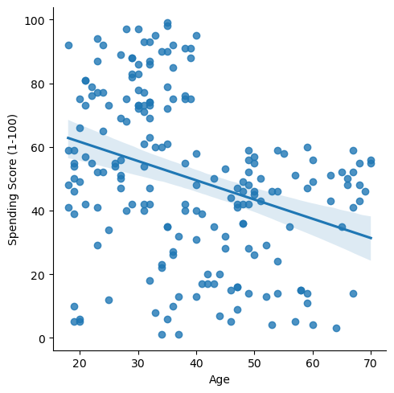

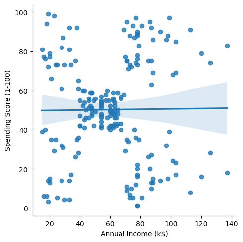

```python
sb.lmplot(data=df, x='Age', y='Annual Income (k$)')
sb.lmplot(data=df, x='Age', y='Spending Score (1-100)')
sb.lmplot(data=df, x='Annual Income (k$)', y='Spending Score (1-100)')
```

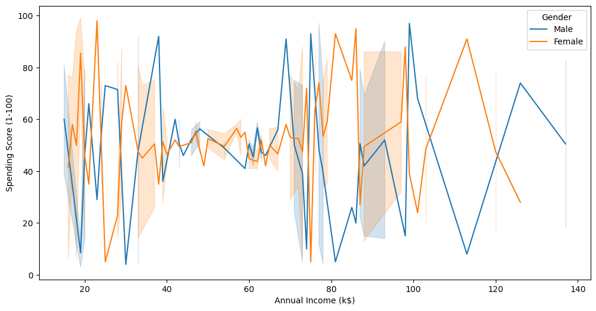

```python
plt.figure(figsize=(12, 6))
sb.lineplot(x='Annual Income (k$)', y='Spending Score (1-100)', hue='Gender', data=df,)
```

```python
newdf = df.drop(columns = ['Age','Gender','CustomerID'])
newdf
```

|  | Annual Income (k$) | Spending Score (1-100) |
| --- | --- | --- |
| 0 | 15 | 39 |
| 1 | 15 | 81 |
| 2 | 16 | 6 |
| 3 | 16 | 77 |
| 4 | 17 | 40 |
| ... | ... | ... |
| 195 | 120 | 79 |
| 196 | 126 | 28 |
| 197 | 126 | 74 |
| 198 | 137 | 18 |
| 199 | 137 | 83 |

200 rows × 2 columns

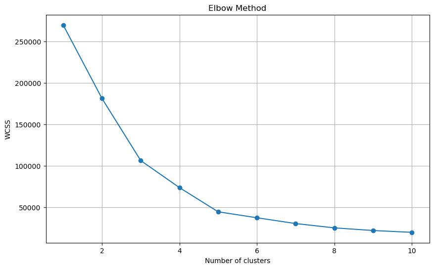

```python
from sklearn.cluster import KMeans
from sklearn.datasets import make_blobs

wcss = []
for i in range(1, 11):
    kmeans = KMeans(n_clusters=i, init='k-means++', max_iter=300, n_init=10, random_state=0)
    kmeans.fit(newdf)
    wcss.append(kmeans.inertia_)

# Plotting the elbow curve
plt.figure(figsize=(10,6))
plt.plot(range(1, 11), wcss, marker='o')
plt.title('Elbow Method')
plt.xlabel('Number of clusters')
plt.ylabel('WCSS')
plt.grid(True)
plt.show()
```

5 clusters creates an elbow, 5 is our optimal number

```python
n_clusters = 5


kmeans = KMeans(n_clusters=n_clusters, init='k-means++', max_iter=300, n_init=10, random_state=0)


kmeans.fit(newdf)


cluster_labels = kmeans.labels_


newdf['Cluster'] = cluster_labels

newdf
```

|  | Annual Income (k$) | Spending Score (1-100) | Cluster |
| --- | --- | --- | --- |
| 0 | 15 | 39 | 0 |
| 1 | 15 | 81 | 3 |
| 2 | 16 | 6 | 0 |
| 3 | 16 | 77 | 3 |
| 4 | 17 | 40 | 0 |
| ... | ... | ... | ... |
| 195 | 120 | 79 | 1 |
| 196 | 126 | 28 | 2 |
| 197 | 126 | 74 | 1 |
| 198 | 137 | 18 | 2 |
| 199 | 137 | 83 | 1 |

200 rows × 3 columns

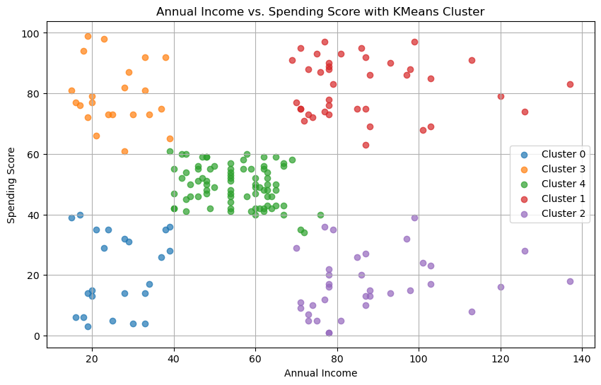

```python
plt.figure(figsize=(10, 6))

for cluster_label in newdf['Cluster'].unique():
    cluster_data = newdf[newdf['Cluster'] == cluster_label]
    plt.scatter(cluster_data['Annual Income (k$)'], cluster_data['Spending Score (1-100)'], label=f'Cluster {cluster_label}', alpha=0.7)


plt.title('Annual Income vs. Spending Score with KMeans Cluster')
plt.xlabel('Annual Income')
plt.ylabel('Spending Score')
plt.legend()
plt.grid(True)
plt.show()
```

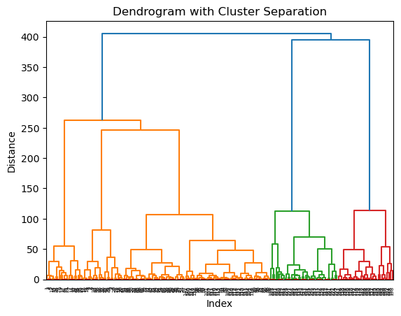

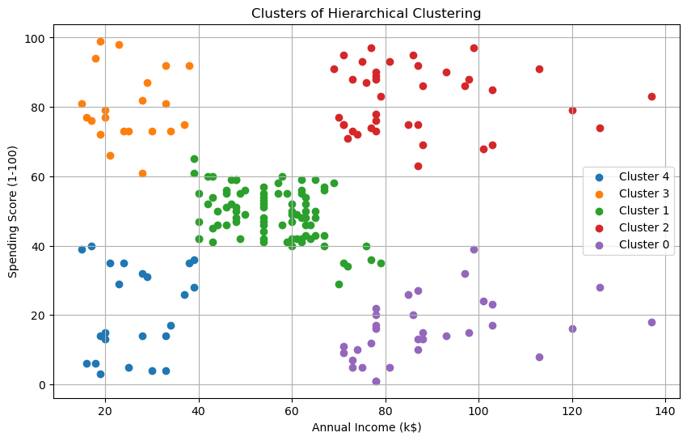

```python
import pandas as pd
import matplotlib.pyplot as plt
import scipy.cluster.hierarchy as sch
from sklearn.cluster import AgglomerativeClustering


dendrogram = sch.dendrogram(sch.linkage(newdf, method='ward'))

threshold = 150  # Example threshold for demonstration
plt.axhline(color='r', linestyle='--')
plt.title('Dendrogram with Cluster Separation')
plt.xlabel('Index')
plt.ylabel('Distance')

model = AgglomerativeClustering(n_clusters=None, linkage='ward', distance_threshold=threshold)
model.fit(newdf)
newdf['Cluster'] = model.labels_

plt.figure(figsize=(10, 6))
for cluster_label in newdf['Cluster'].unique():
    cluster_data = newdf[newdf['Cluster'] == cluster_label]
    plt.scatter(cluster_data['Annual Income (k$)'], cluster_data['Spending Score (1-100)'], label=f'Cluster {cluster_label}')

plt.title('Clusters of Hierarchical Clustering')
plt.xlabel('Annual Income (k$)')
plt.ylabel('Spending Score (1-100)')
plt.legend()
plt.grid(True)
plt.show()
```

it appears that heirarchical clustering produces very similar results to kmeans clustering, however, we can see that cluster 1 has obtained more data points within its radius as opposed to kmeans. We can see that kmeans cares more about having equal, but very distinct clusters of data to identify. Heirarchical clustering is tree based, and as a result, will seek to find more nuanced a detailed patterns within our data outside of just a distance metric, hence, why it is showing extra samples in cluster 1.

With this being said, I would recommend using kmeans clustering for most general purposes, because it is a fairly simple algorithm that is useful in classifying future samples, and works well with data that is already pre-classified, hence, being a supervised algorithm. Its performance is also much better than heirarchical clustering because of how simple its algorithm is.

Perhaps predicting what "genre" of "spender" a new person would be is a good example of what we can use kmeans clustering for.

Heirarchical clustering is useful because it does not require the elbow method to acquire the optimal cluster count, as it doesn't really need any parameters or specified info regardless.

Heirarchical clustering would do its best when we have a small(er) dataset with NO expectations on how the data will be clustered. Heirarchical is useful for finding indepth, hard-to-spot trends within data.

I would recommend heirarchical clustering if we had no idea what to expect from our annual income to spending score graph. Heirarchical clustering would do well to expose these trends and give us needed insight to explore data that we have no info to work with.